# Ford GoBike dataset exploration

## by Maysa Qarqaz

## Investigation Overview

The main goal of this investigation is to find the characterstics of bike users that could affect the trip duration. I will focus on these attributes: Member age and user type.

## Dataset Overview

There are 183412 rides in the dataset with 16 features (duration, start time, end time, start and end stations info :id, name latitude and longitude, bike id, user type, member birth year, member gender and bike share for all trip). Some variables are numerical and other are nominal categorical variables. Time Frame of the data: February 2019

## Trip duration distribution

Trip duration has a wide range of values, starting from 1 min and ending at about 1400 min, the distribution has a long tail with a peak at 10 min.

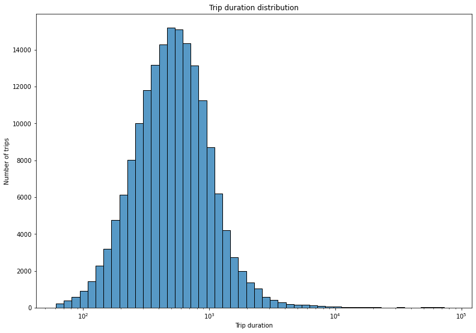

## Member age distribution

Most members are between 20 and 40 years old

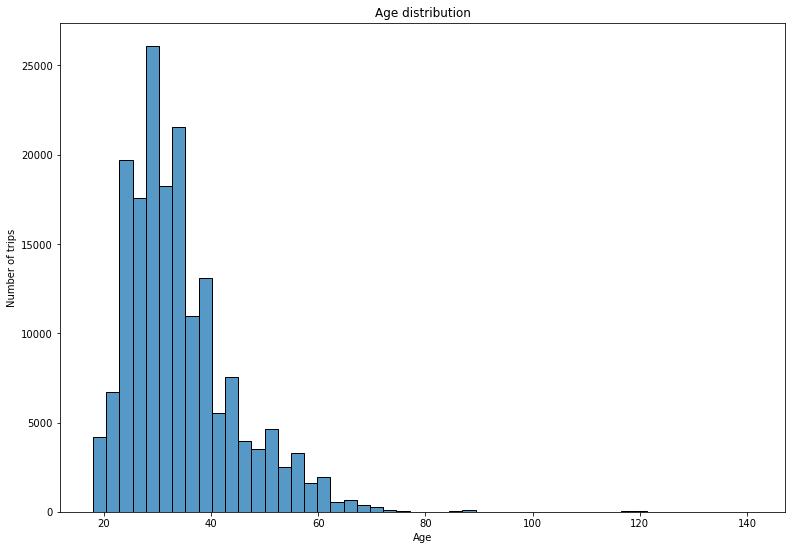

## Trip duration and member age relatioship

Long trips were done by younger users

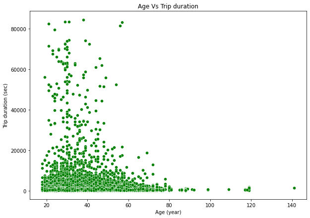

## User type counts

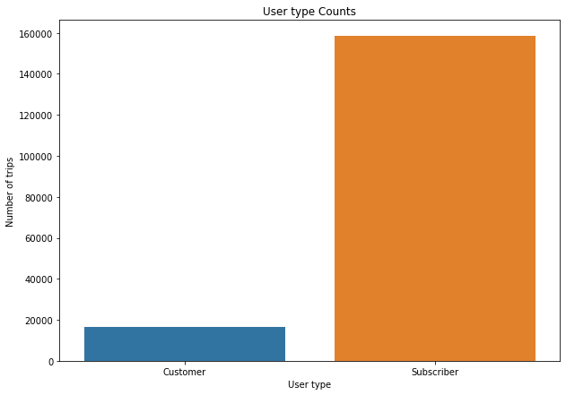

## Trip duration and User type relationship

Customer user type has a larger mean trip duration than subsriber

```
(0.0, 3000.0)
```

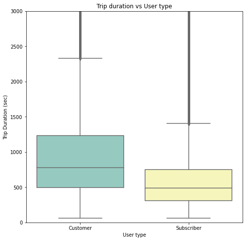